# Project - Assignment 2 - Time Series Analysis

Kinga Bazak, Dawid Cioch, Bartłomiej Gibas

2023-01-25

# TASK 1:

Consider the monthly *sales of products* (see file dane_BDK.csv at UPeL).

1. Make *sales of products* forecasts for each month of the second half of 2021.

## SOLUTION of TASK 1

# Load data

We start with load the data

```r
rawdata <- read.csv("./dane_BDK.csv")
data <- ts(rawdata[3], start=c(2016,7), frequency=12)
```

# Plot data

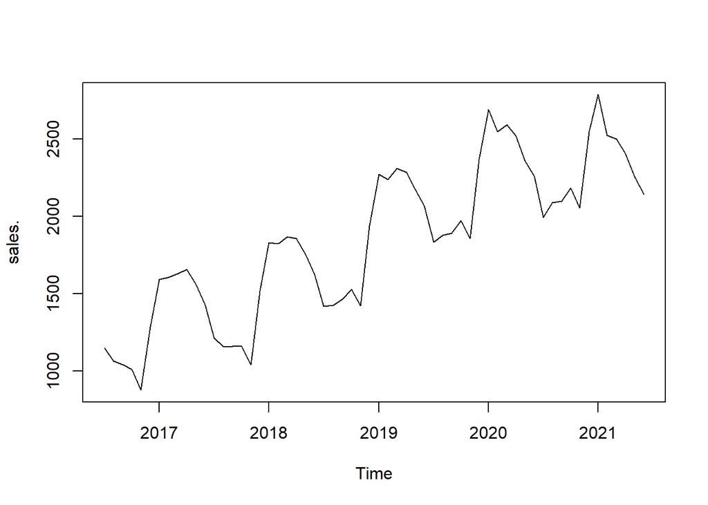

```r
plot.ts(data)
```

We can observe repeated pattern in our data. Let’s separate origin data to components. We decompose our dataset as a additive model.

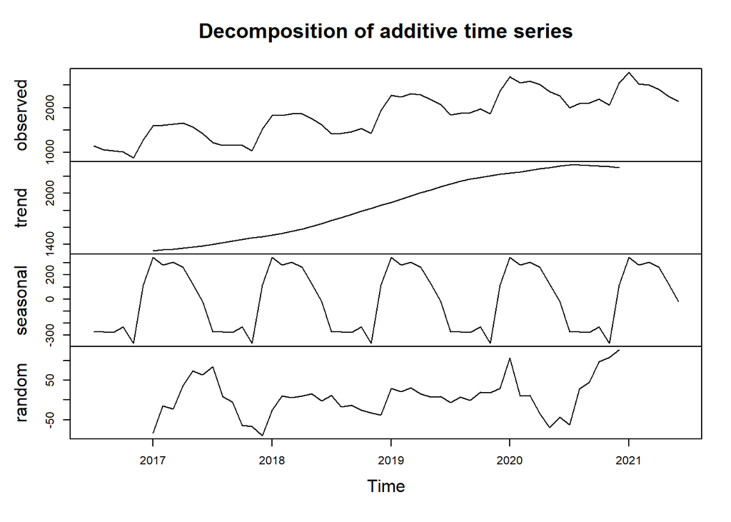

```r
data_decompose <- decompose(data)
plot(data_decompose)
```

We can see that the trend and seasonality information extracted from the series does seem reasonable. We are going to eliminate trend and seasonality from our data.

# Removing seasonality

```r
library(forecast)
```

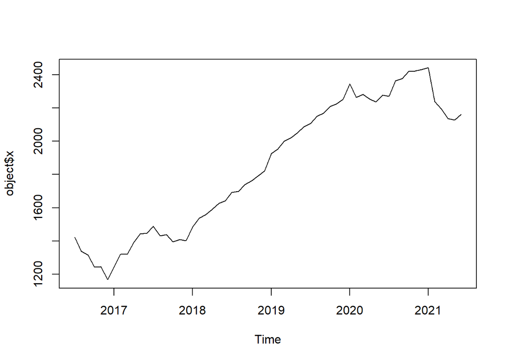

```r
deseason = seasadj(data_decompose)
plot(deseason)
```

# Removing trend

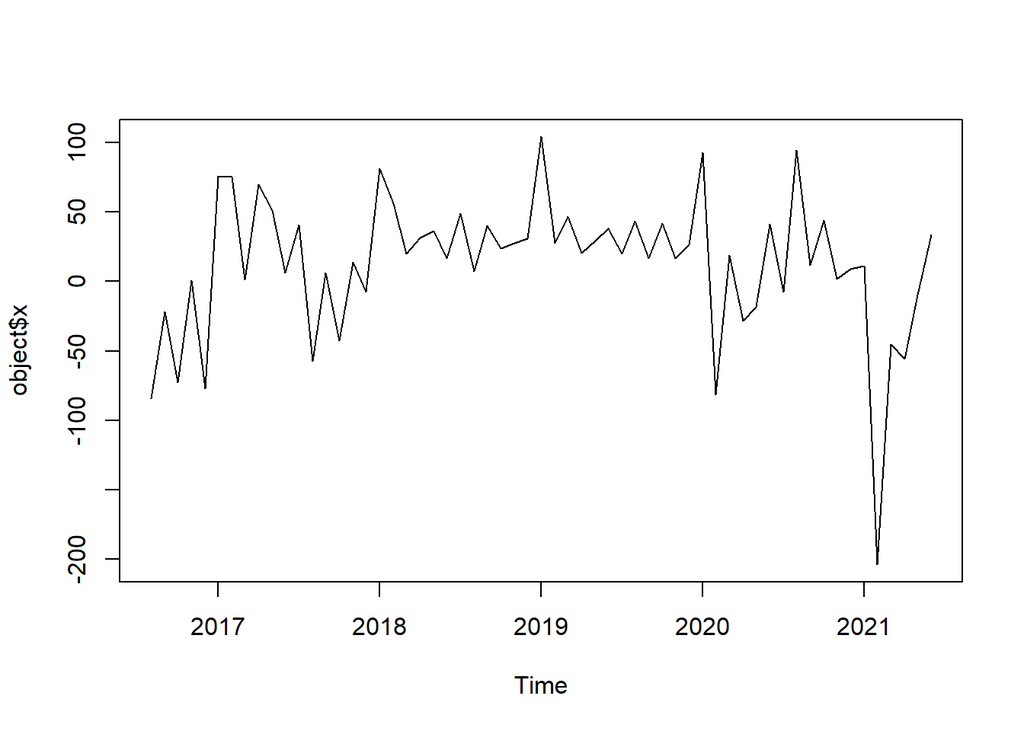

```r
diff <- diff(deseason, lag=1, differences=1)
plot(diff)
```

Below we can observe how our data has changed

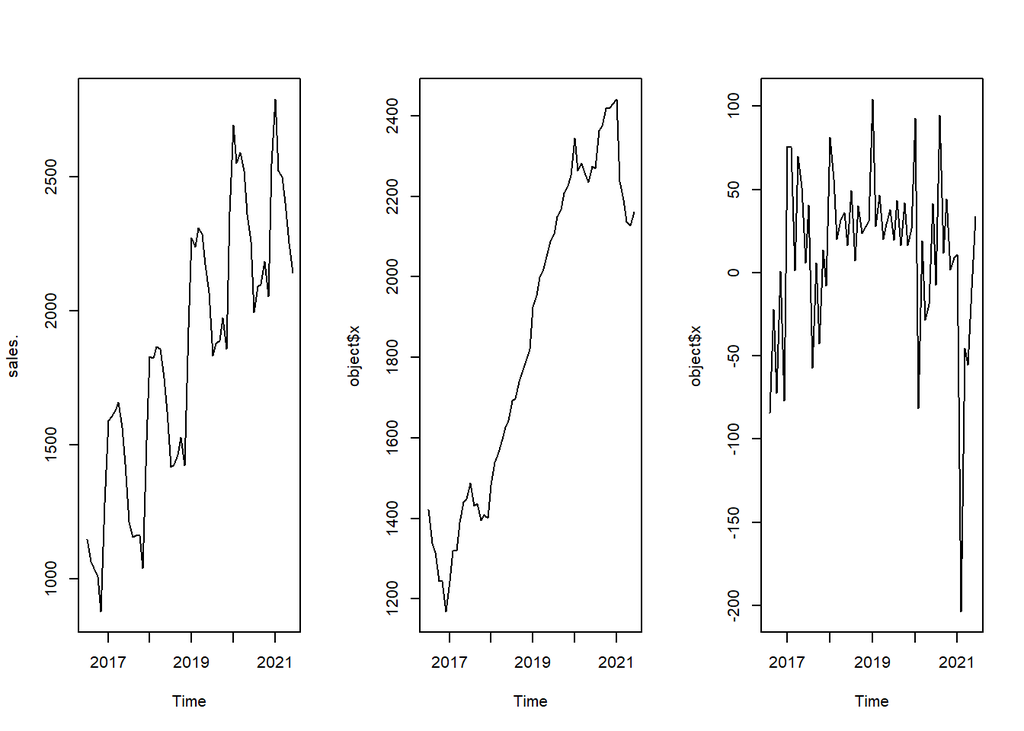

```r
par(mfrow=c(1,3))
plot(data)
plot(deseason)
plot(diff)
```

# ACF and PACF plot

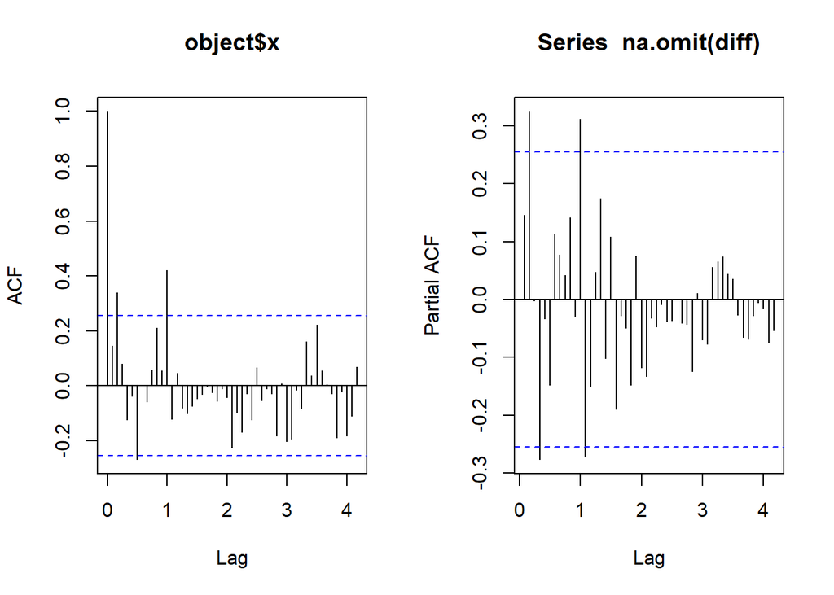

```r
par(mfrow=c(1,2))
acf(na.omit(diff), lag.max=50)
pacf(na.omit(diff), lag.max=50)
```

# Model

```r
model <- Arima(diff, order=c(3,0,2), include.mean=TRUE)
predict <- forecast(model, h=6, level=95)
```

We inverse transformation and calculate bounds of confidence intervals.

```r
invpredict<-c(rep(0,6))
inv_lower_predict<-c(rep(0,6))
inv_upper_predict<-c(rep(0,6))

invpredict[1]=predict$mean[1]+data[60]
for(i in 2:6) {
  invpredict[i]=predict$mean[i]+invpredict[i-1]
}
invpredict<-ts(invpredict, start=c(2021,7), freq=12)

inv_lower_predict[1]=predict$lower[1]+data[60]
for(i in 2:6) {
  inv_lower_predict[i]=predict$lower[i]+invpredict[i-1]
}
inv_lower_predict<-ts(inv_lower_predict, start=c(2021,7), freq=12)

inv_upper_predict[1]=predict$upper[1]+data[60]
for(i in 2:6) {
  inv_upper_predict[i]=predict$upper[i]+invpredict[i-1]
}
inv_upper_predict<-ts(inv_upper_predict, start=c(2021,7), freq=12)
```

# Prediction

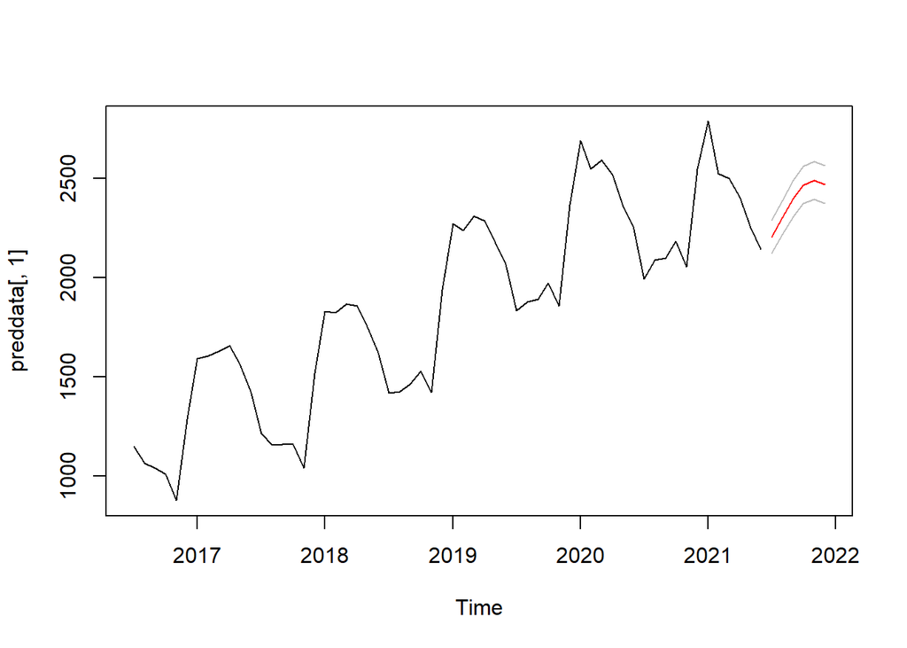

```r
preddata<-cbind(data,invpredict)
ts.plot(preddata[,1])
lines(preddata[,2], col="red")
lines(inv_upper_predict, col="gray")
lines(inv_lower_predict, col="gray")
```

# TASK 2:

Consider the [Bartłomiej’s time series from Lab 1 task 4.1](https://upel.agh.edu.pl/mod/forum/discuss.php?d=126) (Road Casualties in Great Britain 1969-84) 1. Make all necessary transformations to get a stationary time series (noise).  
2. If possible, choose the ARMA (p, q) model for stationary noise.

## TASK 2

## Database UKDriverDeaths

Short description from CRAN-R:

UKDriverDeaths is a time series giving the monthly totals of car drivers in Great Britain killed or seriously injured Jan 1969 to Dec 1984. Compulsory wearing of seat belts was introduced on 31 Jan 1983.

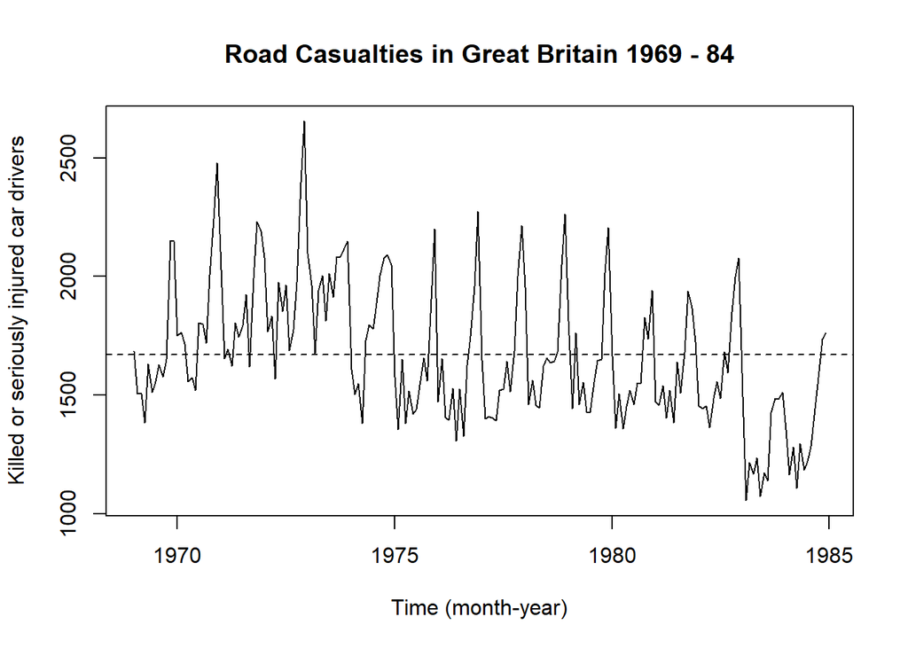

```r
# Load the data
data(UKDriverDeaths)
df = UKDriverDeaths
plot.ts(df, main='Road Casualties in Great Britain 1969 - 84',
        xlab='Time (month-year)',
        ylab='Killed or seriously injured car drivers')
# dotted line is the mean of the data
abline(h=mean(df), lty=2)
```

To prevent possible problems with changing variance over time, we will use a Box-Cox transformation.

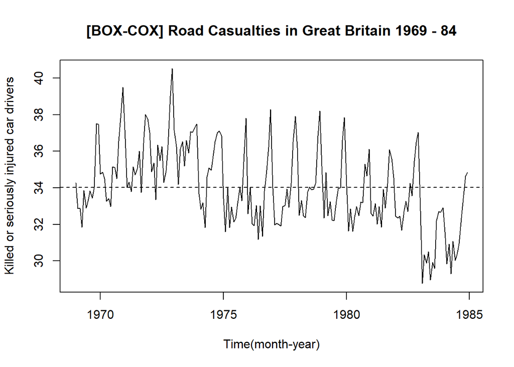

```r
# Box-Cox
library(forecast)
df = BoxCox(df,lambda="auto")
plot.ts(df, main='[BOX-COX] Road Casualties in Great Britain 1969 - 84',
        xlab='Time(month-year)',
        ylab='Killed or seriously injured car drivers')
abline(h=mean(df), lty=2)
```

Now let’s take a look at the ACF and PACF charts…

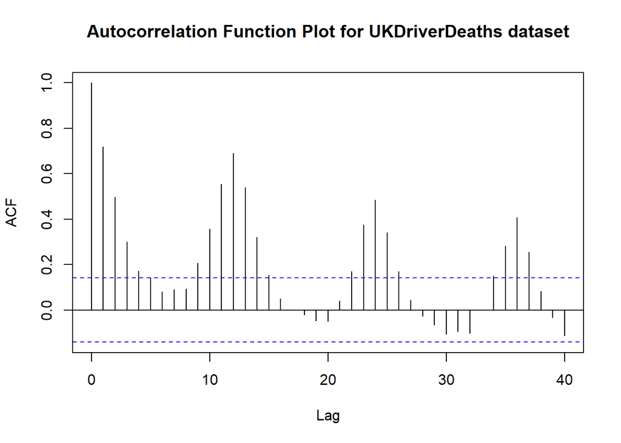

```r
stats::acf(as.numeric(df), lag.max=40, ci=.95,
    main=" Autocorrelation Function Plot for UKDriverDeaths dataset ")
```

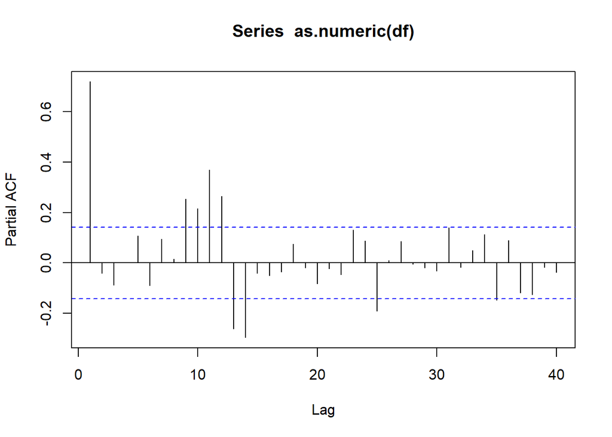

```r
pacf(as.numeric(df), lag.max=40, ci=.95)
```

From the graphs above, we infer that there is seasonality and possibly a trend in our data, so we will now try to remove it. Based on experience, we expect annual seasonality in the number of casualties/accidents.Let’s look at the chart, taking into account the volatility in individual months.

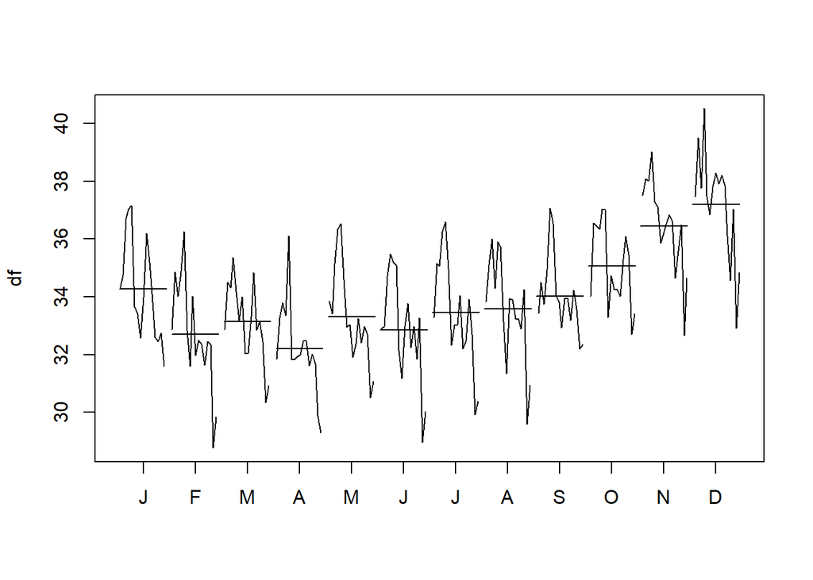

```r
monthplot(df)
```

Our assumptions were confirmed. We now remove seasonality (d=12) using differentiation in the following way.

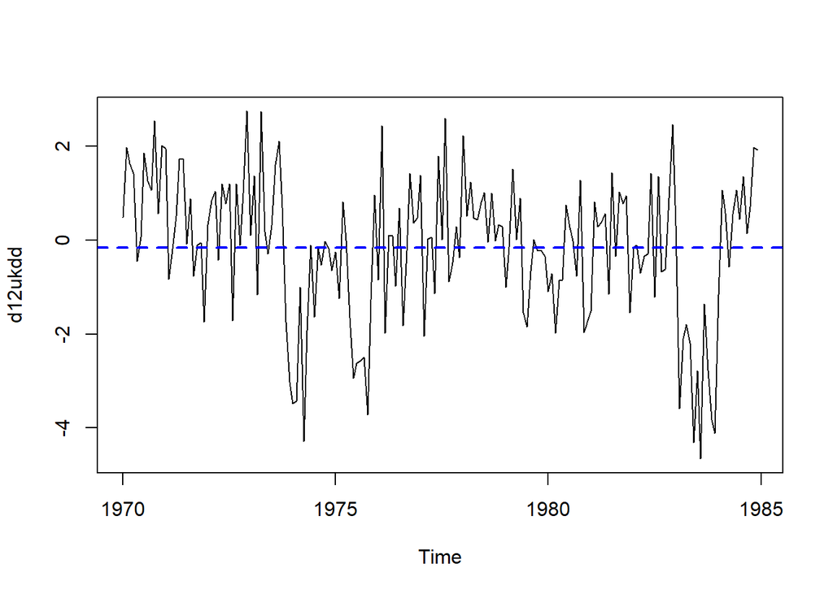

```r
# deseasonality data d=12
# 12 msc
d12ukdd<-diff(df,12)
# generate plot of differentiated data
plot.ts(d12ukdd)
abline(h=mean(d12ukdd), lty=2, col='blue', lwd=2)
```

Let’s take a look at the ACF and Partial ACF charts again but this time for deseasonalized data
$$\nabla_{12}\{X_t\}.$$

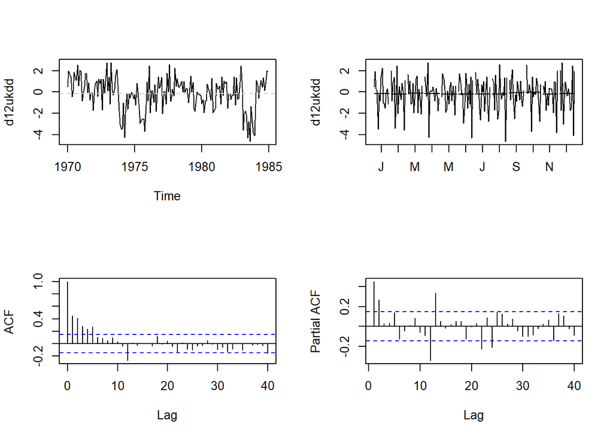

```r
par(mfrow=c(2,2))
plot.ts(d12ukdd); abline(h=mean(d12ukdd),lty=2, col='lightblue')
monthplot(d12ukdd)

LM=40 # lag.max
acf(as.numeric(d12ukdd), lag.max = LM, main="")
pacf(as.numeric(d12ukdd), lag.max = LM, main="")
```

Please notice that there is some trend in our data. In order for our series to be stationary, we must remove it. We will do this - in the simple way - by differentiating.

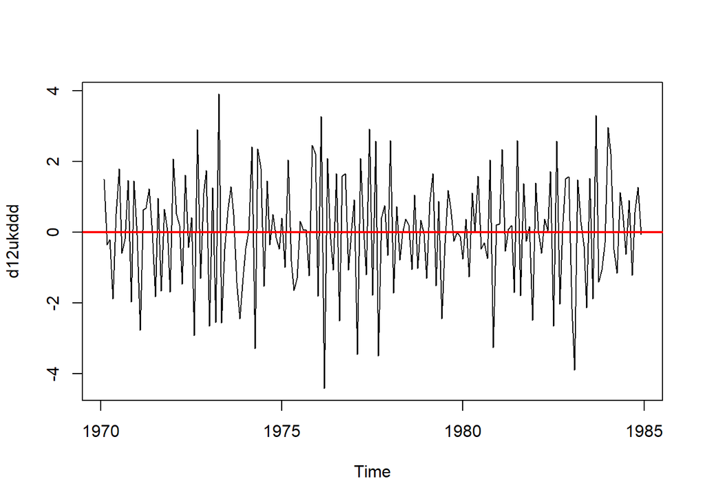

```r
# diff - removing trend
d12ukddd <- diff(d12ukdd,1)
# generate plot the data without trend
plot(d12ukddd)
# add the dotted line (it is mean of the data)
abline(h=mean(d12ukddd), lwd=2, col='red')
```

We have
$$\nabla_1\nabla_{12}\{X_{t}\}.$$
Let’s re-examine the ACF and PACF charts. What can we say about them? In addition, let’s check if our rest (after deducting seasonality and trend) are normal. We will generate a plot box.

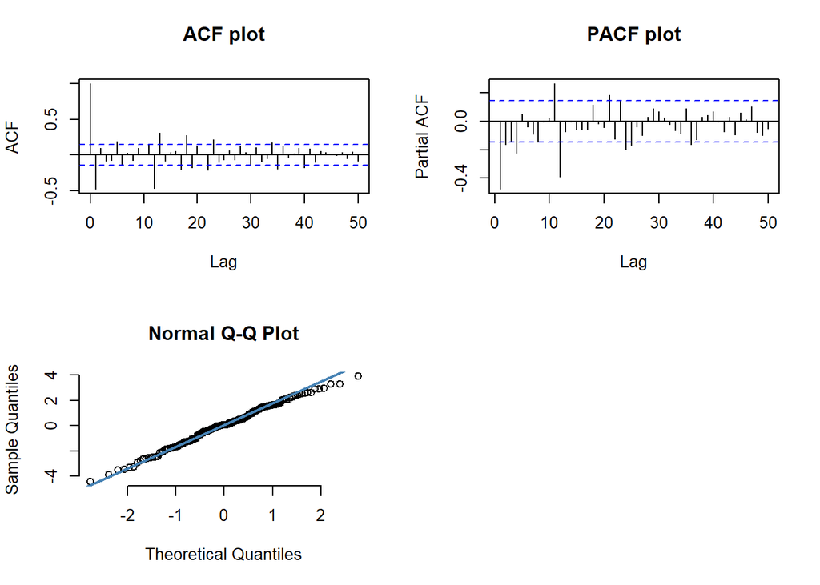

```r
par(mfrow=c(2,2))
# generating plots
acf(as.numeric(d12ukddd), lag.max=50, main='ACF plot')
pacf(as.numeric(d12ukddd), lag.max=50, main='PACF plot')
# check normality of residuals
qqnorm(d12ukddd, pch = 1, frame = FALSE)
qqline(d12ukddd, col = "steelblue", lwd = 2)
```

From above, we can assume that the autocorrelations decreases in magnitude with increasing lag. From the partial autocorrelogram, we can see that the partial autocorrelations tail off to zero after lag 12 (in this lag in negative).

To sum up, we can use for this time series an ARMA(12,0) [AR(12) to be precisious] since the partial autocorrelogram is zero after lag 12 and the correlogram tails off to zero after lag (approx.) 12.

```r
# The mean of our residuals is very close to zero (0.01) but however we put it into ARMA model.
MODEL_AR_1<-arima(d12ukddd,order=c(12,0,0),include.mean =TRUE)
```

We have our model. Now we can do a prediction for, say, the next 12 months. Let’s see what the results will be. Remember that we need to reverse the differentiation and Box-Cox process for the results to be interpretable.

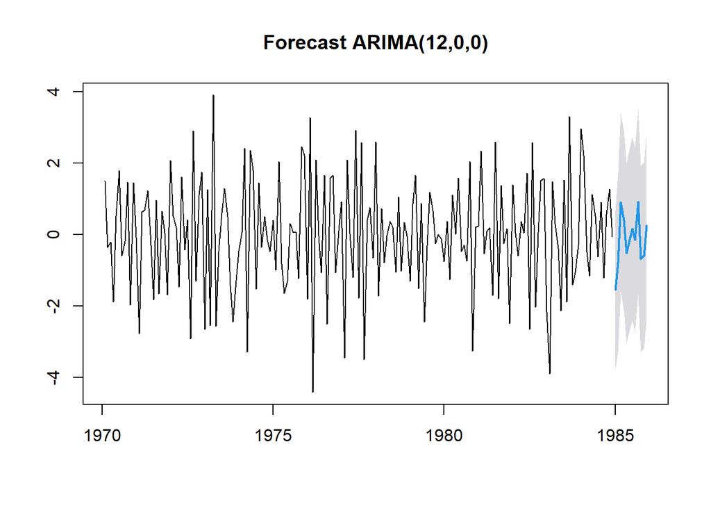

```r
future<-forecast(MODEL_AR_1,h=12,level=95)
plot(future,main='Forecast ARIMA(12,0,0)')
```

Now, we invert Box-Cox transformation (we executed it with $\lambda=0.3424065$ before). Therefore if we mark by $y_i$ “true” value before BC transformation and $Y_i$ after, we obtain for non-zero $\lambda$
$$Y_i = \frac{(y_i^{\lambda}-1)}{\lambda},$$
the following formula
$$y_i =
\sqrt[\lambda]{\lambda Y + 1}.$$
Without going into details (calculation etc. because it is very easy in this case), we come to predictions.

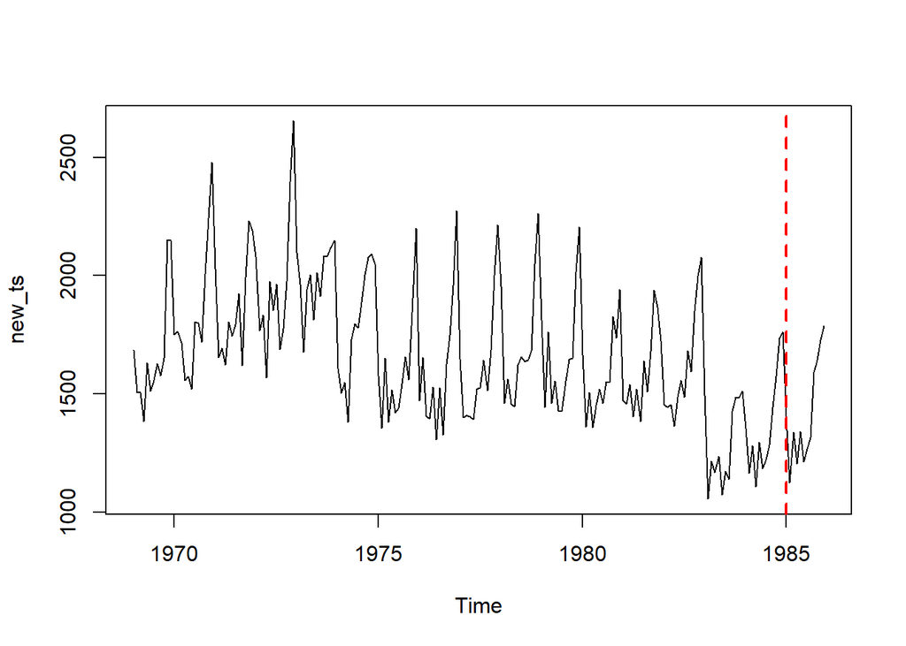

```r
A<-c(rep(0,12))
A[1]=future$mean[1]+d12ukdd[180]+df[181]
A[2]=future$mean[2]+A[1]+df[182] - df[181]
A[3]=future$mean[3]+A[2]+df[183] - df[182]

for(i in 4:12){
  A[i]=future$mean[i]+A[i-1]+df[184+i-4]-df[184+i-5]
}

for(i in 1:12){
  A[i]=(0.3424065*A[i]+1)^(1/0.3424065)
}
vec = c(UKDriverDeaths,A)
new_ts = ts(vec,start=c(1969,1), freq=12)
plot.ts(new_ts)
abline(v=1985, col='red',lwd=2, lty=2)
```

Our prediction starts from the red line.